# ADHD rx and suicide multinational

# 1 README

Title of Proposed Research: The use of ADHD medication and the risk of self-harm: A multinational population-based self-controlled case series study

This Statistical Analysis Plan describes the codes used for meta-analysing the aggregated outputs from different databases.

Principal investigator(s): Adrienne Chan, Kenneth Man, Ian Wong  
Main analyst(s): Adrienne Chan  
Nominated second/third independent analyst(s): Kirstie TW Wong, Andrew Yuen  
Publicly available on any websites? https://github.com/adrienneylc

Version 1: 20250127

# 2 Load packages

Packages used:  
1. data manipulation: dplyr, tidyr, stringr, stringi, data.table, Hmisc, haven  
2. data visualisation: ggplot2, grid, forestplot, directlabels, RColorBrewer  
3. statistical analyses: epitools, ratesci, metafor, meta, splines, Rcan

# 3 Analysis

Analysis outputs followed the order of:  
1. overall exposure vs overall nonexposure  
2. 90 days before ADHD medication initiation vs baseline period (i.e. unexposed period without the 90 days preexposure)  
3. First 90 days of ADHD medication initiation vs baseline period  
4. Subsequent ADHD medication initiation vs baseline period

## 3.1 Main analysis

```r
library(readxl)


setwd("G:/enter/4_bouken/2024_4 ADHD Suicide/R")
risk<-read_excel("./risk_results.xlsx")
library(meta)

risk_main<-subset(risk, Analysis=="main" )
m.gen <- metagen(TE = log(IRR),
                 lower=log(IRR_Lower),
                 upper=log(IRR_Upper),
                 studlab = Country,
                 data = risk_main,
                 event.e=risk_main$Case_inc,
                 event.c=risk_main$Control_inc,
                 n.e=Case_total,
                 n.c=Control_total,
                 sm = "IRR",
                 fixed = FALSE,
                 random = TRUE,
                 method.tau = "DL",
                 title = "Main analysis")
main<-forest(m.gen,
       col.square="cornflowerblue",
                 title = "Overall",
        ff.heading = "bold",
col.i.inside.square="black",
#col.study = "red",
       col.study = "black",col.diamond.random = "darkblue",
       col.diamond.lines = "black",
       col.diamond.lines.random = "black",
       xlim = c(0.2,5),
       col.by="navy",
       lab.e=NULL, lab.c=NULL,
label=T,
         leftcols = c("studlab", "n.e", "n.c"),
       leftlabs=c("Country","Exposed \n person-years","Unexposed \n person-years" ),
       rightlabs=c("(IRR)","95% CI","Weight" ))
```

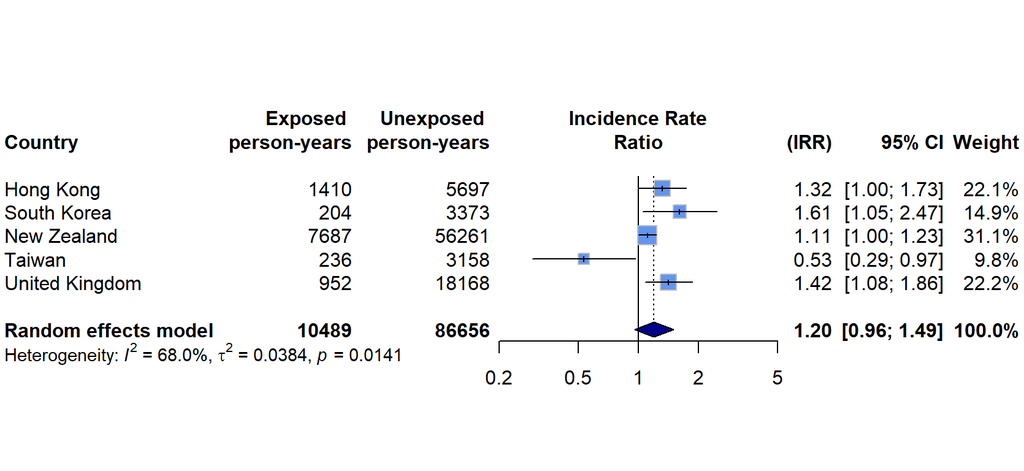

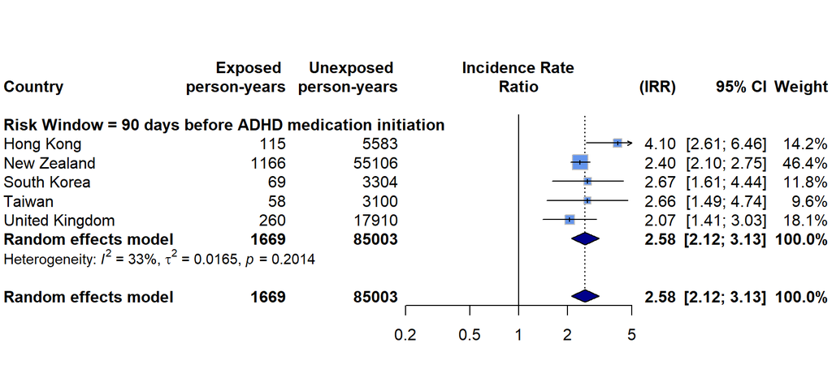

```r
library(readxl)
rp<-read_excel("./riskperiod_results.xlsx")


library(meta)
rp$IRR<-as.numeric(rp$IRR)
rp$IRRLCI<-as.numeric(rp$IRRLCI)
rp$IRRUCI<-as.numeric(rp$IRRUCI)
rp$Case_inc<-as.numeric(rp$Case_inc)
rp$Control_inc<-as.numeric(rp$Control_inc)
rp$Case_total<-as.numeric(rp$Case_total)
rp$Control_total<-as.numeric(rp$Control_total)


rp_main_pre90<-subset(rp, Analysis=="Main" & `Risk Window`=="90 days before ADHD medication initiation")
m.gen <- metagen(TE = log(IRR),
                 lower=log(IRRLCI),
                 upper=log(IRRUCI),
                 studlab = Country,
                 data = rp_main_pre90,
                 event.e=rp_main_pre90$Case_inc,
                 event.c=rp_main_pre90$Control_inc,
                 n.e=Case_total,
                 n.c=Control_total,
                 sm = "IRR",
                 fixed = FALSE,
                 random = TRUE,
                 method.tau = "DL",byvar = `Risk Window`,
                 title = "Main analysis", subgroup =  `Risk Window`)
library(forestplot)
library(dplyr)



main_pre90<-forest(m.gen,
       col.square="cornflowerblue",
        ff.heading = "bold",
col.i.inside.square="black",
       col.diamond.random = "darkblue",
       col.diamond.lines = "black",
       col.diamond.lines.random = "black",
       xlim = c(0.2,5),
       col.by="black",
       lab.e=NULL, lab.c=NULL, label=T,
          leftcols = c("studlab", "n.e", "n.c"),
       leftlabs=c("Country","Exposed \n person-years","Unexposed \n person-years" ),
       rightlabs=c("(IRR)","95% CI","Weight" ),
overall.hetstat=F,  test.subgroup=F)
```

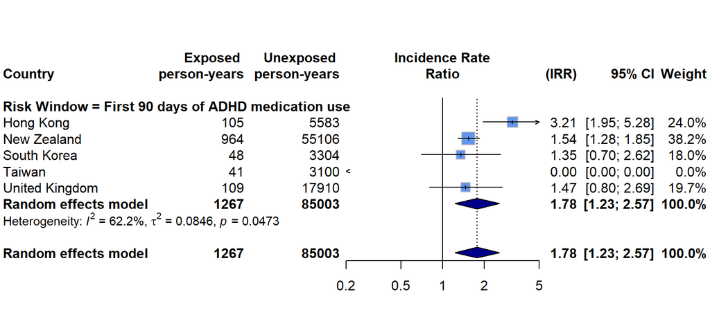

```r
library(readxl)
rp<-read_excel("./riskperiod_results.xlsx")

#Spittal, M.J., Pirkis, J. & Gurrin, L.C. Meta-analysis of incidence rate data in the presence of zero events. BMC Med Res Methodol 15, 42 (2015). https://doi.org/10.1186/s12874-015-0031-0

library(meta)
rp$IRR<-as.numeric(rp$IRR)
rp$IRRLCI<-as.numeric(rp$IRRLCI)
rp$IRRUCI<-as.numeric(rp$IRRUCI)
rp$Case_inc<-as.numeric(rp$Case_inc)
rp$Control_inc<-as.numeric(rp$Control_inc)
rp$Case_total<-as.numeric(rp$Case_total)
rp$Control_total<-as.numeric(rp$Control_total)


rp_main_pre90<-subset(rp, Analysis=="Main" & `Risk Window`=="First 90 days of ADHD medication use" )
m.gen <- metagen(TE = log(IRR),
                 lower=log(IRRLCI),
                 upper=log(IRRUCI),
                 studlab = Country,
                 data = rp_main_pre90,
                 event.e=rp_main_pre90$Case_inc,
                 event.c=rp_main_pre90$Control_inc,
                 n.e=Case_total,
                 n.c=Control_total,
                 leftcols=c("studlab", "event.e", "n.e", "event.c", "n.c"),
                 sm = "IRR",
                 fixed = FALSE,
                 random = TRUE,
                 method.tau = "DL",
                 title = "Main analysis", subgroup =  `Risk Window`)


library(forestplot)
library(dplyr)

main_pre90<-forest(m.gen,
       col.square="cornflowerblue",
        ff.heading = "bold",
col.i.inside.square="black",
       col.diamond.random = "darkblue",
       col.diamond.lines = "black",
       col.diamond.lines.random = "black",
       xlim = c(0.2,5),
       col.by="black",
       lab.e=NULL, lab.c=NULL, label=T,
                leftcols = c("studlab", "n.e", "n.c"),
       leftlabs=c("Country","Exposed \n person-years","Unexposed \n person-years" ),
       rightlabs=c("(IRR)","95% CI","Weight" ),
overall.hetstat=F,  test.subgroup=F)
```

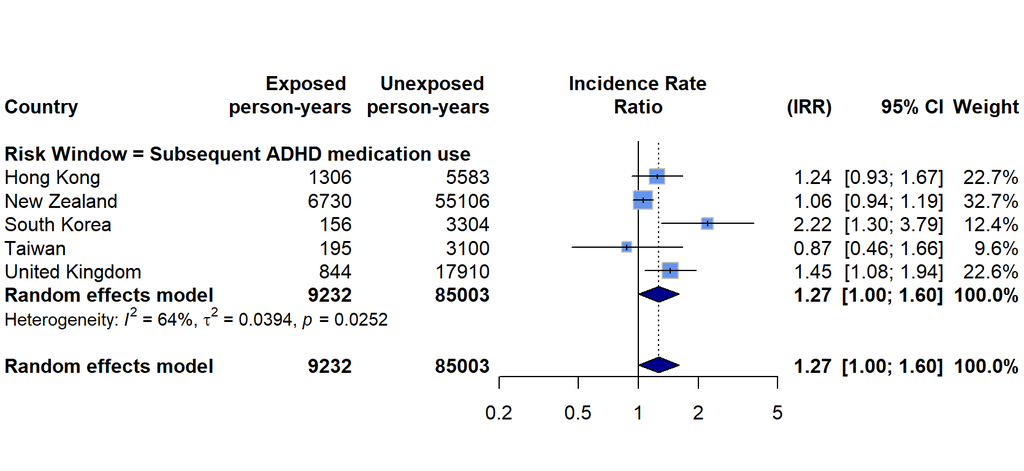

```r
library(meta)

rp_main_pre90<-subset(rp, Analysis=="Main" & `Risk Window`=="Subsequent ADHD medication use")
m.gen <- metagen(TE = log(IRR),
                 lower=log(IRRLCI),
                 upper=log(IRRUCI),
                 studlab = Country,
                 data = rp_main_pre90,
                 event.e=rp_main_pre90$Case_inc,
                 event.c=rp_main_pre90$Control_inc,
                 n.e=Case_total,
                 n.c=Control_total,
                 sm = "IRR",
                 fixed = FALSE,
                 random = TRUE,
   #              subgroup=`Risk Window`,
                 method.tau = "DL",
                 title = "Main analysis", subgroup =  `Risk Window`)
library(forestplot)
library(dplyr)



main_pre90<-forest(m.gen,
       col.square="cornflowerblue",
        ff.heading = "bold",
col.i.inside.square="black",
       col.diamond.random = "darkblue",
       col.diamond.lines = "black",
       col.diamond.lines.random = "black",
       xlim = c(0.2,5),
       col.by="black",
       lab.e=NULL, lab.c=NULL, label=T,
         leftcols = c("studlab", "n.e", "n.c"),
       leftlabs=c("Country","Exposed \n person-years","Unexposed \n person-years" ),
       rightlabs=c("(IRR)","95% CI","Weight" ),
overall.hetstat=F,  test.subgroup=F)
```

## 3.2 Subgroup: Stimulants

```r
library(meta)


risk_main<-subset(risk, Analysis=="stim" )
m.gen <- metagen(TE = log(IRR),
                 lower=log(IRR_Lower),
                 upper=log(IRR_Upper),
                 studlab = Country,
                 data = risk_main,
                 event.e=rp_main_pre90$Case_inc,
                 event.c=rp_main_pre90$Control_inc,
                 n.e=Case_total,
                 n.c=Control_total,
                 sm = "IRR",
                 fixed = FALSE,
                 random = TRUE,
                 method.tau = "DL",
                 title = "Main analysis")

main<-forest(m.gen,
       col.square="cornflowerblue",
                 title = "Overall",
        ff.heading = "bold",
col.i.inside.square="black",
#col.study = "red",
       col.study = "black",col.diamond.random = "darkblue",
       col.diamond.lines = "black",
       col.diamond.lines.random = "black",
       xlim = c(0.2,5),
       col.by="navy",
       lab.e=NULL, lab.c=NULL,
label=T,
         leftcols = c("studlab", "n.e", "n.c"),
       leftlabs=c("Country","Exposed \n person-years","Unexposed \n person-years" ),
       rightlabs=c("(IRR)","95% CI","Weight" ))
```

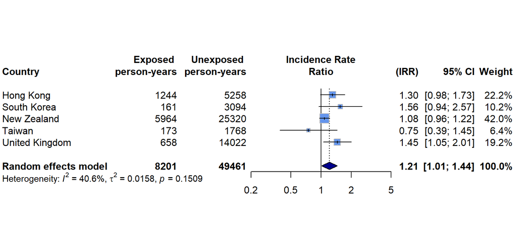

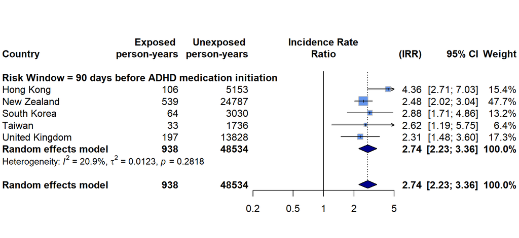

```r
library(meta)

rp_main_pre90<-subset(rp, Analysis=="Stimulants" & `Risk Window`=="90 days before ADHD medication initiation" )
m.gen <- metagen(TE = log(IRR),
                 lower=log(IRRLCI),
                 upper=log(IRRUCI),
                 studlab = Country,
                 data = rp_main_pre90,
                 event.e=rp_main_pre90$Case_inc,
                 event.c=rp_main_pre90$Control_inc,
                 n.e=Case_total,
                 n.c=Control_total,
                 sm = "IRR",
                 fixed = FALSE,
                 random = TRUE,
                subgroup=`Risk Window`,
                 method.tau = "DL",
                 title = "Main analysis")
library(forestplot)
library(dplyr)



main_pre90<-forest(m.gen,
       col.square="cornflowerblue",
        ff.heading = "bold",
col.i.inside.square="black",
       col.diamond.random = "darkblue",
       col.diamond.lines = "black",
       col.diamond.lines.random = "black",
       xlim = c(0.2,5),
       col.by="black",
       lab.e=NULL, lab.c=NULL, label=T,
         leftcols = c("studlab", "n.e", "n.c"),
       leftlabs=c("Country","Exposed \n person-years","Unexposed \n person-years" ),
       rightlabs=c("(IRR)","95% CI","Weight" ),
overall.hetstat=F,  test.subgroup=F)
```

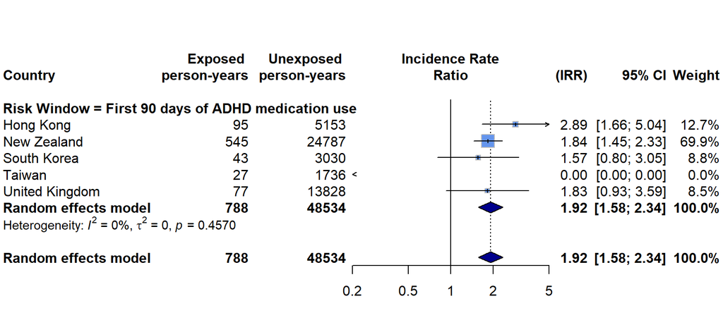

```r
library(meta)


rp_main_pre90<-subset(rp, Analysis=="Stimulants" & `Risk Window`=="First 90 days of ADHD medication use" )
m.gen <- metagen(TE = log(IRR),
                 lower=log(IRRLCI),
                 upper=log(IRRUCI),
                 studlab = Country,
                 data = rp_main_pre90,
                 event.e=rp_main_pre90$Case_inc,
                 event.c=rp_main_pre90$Control_inc,
                 n.e=Case_total,
                 n.c=Control_total,
                 sm = "IRR",
                 fixed = FALSE,
                 random = TRUE,
                 subgroup=`Risk Window`,
                 method.tau = "DL",
                 title = "Main analysis")
library(forestplot)
library(dplyr)

main_pre90<-forest(m.gen,
       col.square="cornflowerblue",
        ff.heading = "bold",
col.i.inside.square="black",
       col.diamond.random = "darkblue",
       col.diamond.lines = "black",
       col.diamond.lines.random = "black",
       xlim = c(0.2,5),
       col.by="black",
       lab.e=NULL, lab.c=NULL, label=T,
         leftcols = c("studlab", "n.e", "n.c"),
       leftlabs=c("Country","Exposed \n person-years","Unexposed \n person-years" ),
       rightlabs=c("(IRR)","95% CI","Weight" ),
overall.hetstat=F,  test.subgroup=F)
```

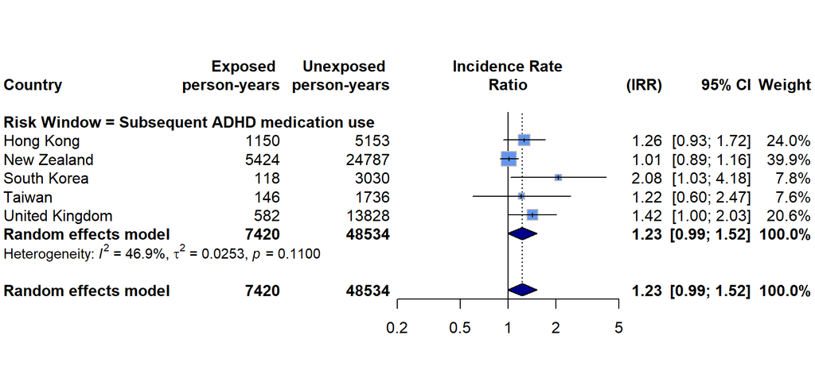

```r
library(meta)

rp_main_pre90<-subset(rp, Analysis=="Stimulants" & `Risk Window`=="Subsequent ADHD medication use" )
m.gen <- metagen(TE = log(IRR),
                 lower=log(IRRLCI),
                 upper=log(IRRUCI),
                 studlab = Country,
                 data = rp_main_pre90,
                 event.e=rp_main_pre90$Case_inc,
                 event.c=rp_main_pre90$Control_inc,
                 n.e=Case_total,
                 n.c=Control_total,
                 sm = "IRR",
                 fixed = FALSE,
                 random = TRUE,
                 subgroup=`Risk Window`,
                 method.tau = "DL")
library(forestplot)
library(dplyr)
main_pre90<-forest(m.gen,
       col.square="cornflowerblue",
        ff.heading = "bold",
col.i.inside.square="black",
       col.diamond.random = "darkblue",
       col.diamond.lines = "black",
       col.diamond.lines.random = "black",
       xlim = c(0.2,5),
       col.by="black",
       lab.e=NULL, lab.c=NULL, label=T,
         leftcols = c("studlab", "n.e", "n.c"),
       leftlabs=c("Country","Exposed \n person-years","Unexposed \n person-years" ),
       rightlabs=c("(IRR)","95% CI","Weight" ),
overall.hetstat=F,  test.subgroup=F)
```

## 3.3 Subgroup: Non-stimulants

```r
library(meta)


risk_main<-subset(risk, Analysis=="nons" )

m.gen <- metagen(TE = log(IRR),
                 lower=log(IRR_Lower),
                 upper=log(IRR_Upper),
                 studlab = Country,
                 data = risk_main,
                 event.e=risk_main$Case_inc,
                 event.c=risk_main$Control_inc,
                 n.e=Case_total,
                 n.c=Control_total,
                 sm = "IRR",
                 fixed = FALSE,
                 random = TRUE,
                 method.tau = "DL",
                 title = "Main analysis")
main<-forest(m.gen,
       col.square="cornflowerblue",
                 title = "Overall",
        ff.heading = "bold",
col.i.inside.square="black",
#col.study = "red",
       col.study = "black",col.diamond.random = "darkblue",
       col.diamond.lines = "black",
       col.diamond.lines.random = "black",
       xlim = c(0.2,5),
       col.by="navy",
       lab.e=NULL, lab.c=NULL,
label=T,
         leftcols = c("studlab", "n.e", "n.c"),
       leftlabs=c("Country","Exposed \n person-years","Unexposed \n person-years" ),
       rightlabs=c("(IRR)","95% CI","Weight" ))
```

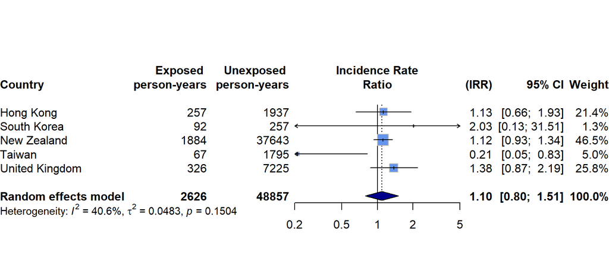

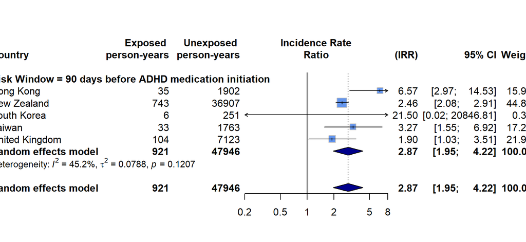

```r
library(meta)

rp_main_pre90<-subset(rp, Analysis=="Non-stimulants" & `Risk Window`=="90 days before ADHD medication initiation" )

m.gen <- metagen(TE = log(IRR),
                 lower=log(IRRLCI),
                 upper=log(IRRUCI),
                 studlab = Country,
                 data = rp_main_pre90,
                 event.e=rp_main_pre90$Case_inc,
                 event.c=rp_main_pre90$Control_inc,
                 n.e=Case_total,
                 n.c=Control_total,
                 sm = "IRR",
                 fixed = FALSE,
                 random = TRUE,
                 subgroup=`Risk Window`,
                 method.tau = "DL",
                 title = "Main analysis")
library(forestplot)
library(dplyr)

main_pre90<-forest(m.gen,
       col.square="cornflowerblue",
        ff.heading = "bold",
col.i.inside.square="black",
       col.diamond.random = "darkblue",
       col.diamond.lines = "black",
       col.diamond.lines.random = "black",
       xlim = c(0.2,8),
       col.by="black",
       lab.e=NULL, lab.c=NULL, label=T,
         leftcols = c("studlab", "n.e", "n.c"),
       leftlabs=c("Country","Exposed \n person-years","Unexposed \n person-years" ),
       rightlabs=c("(IRR)","95% CI","Weight" ),
overall.hetstat=F,  test.subgroup=F)
```

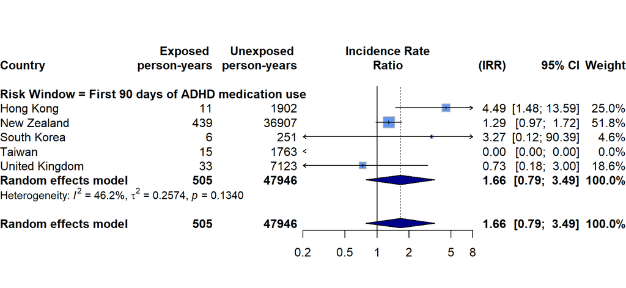

```r
library(meta)
rp_main_pre90<-subset(rp, Analysis=="Non-stimulants" & `Risk Window`=="First 90 days of ADHD medication use" )
m.gen <- metagen(TE = log(IRR),
                 lower=log(IRRLCI),
                 upper=log(IRRUCI),
                 studlab = Country,
                 data = rp_main_pre90,
                 event.e=rp_main_pre90$Case_inc,
                 event.c=rp_main_pre90$Control_inc,
                 n.e=Case_total,
                 n.c=Control_total,
                 sm = "IRR",
                 fixed = FALSE,
                 random = TRUE,
                 subgroup=`Risk Window`,
                 method.tau = "DL",
                 title = "Main analysis")
library(forestplot)
library(dplyr)

main_pre90<-forest(m.gen,
       col.square="cornflowerblue",
        ff.heading = "bold",
col.i.inside.square="black",
       col.diamond.random = "darkblue",
       col.diamond.lines = "black",
       col.diamond.lines.random = "black",
       xlim = c(0.2,8),
       col.by="black",
       lab.e=NULL, lab.c=NULL, label=T,
         leftcols = c("studlab", "n.e", "n.c"),
       leftlabs=c("Country","Exposed \n person-years","Unexposed \n person-years" ),
       rightlabs=c("(IRR)","95% CI","Weight" ),
overall.hetstat=F,  test.subgroup=F)
```

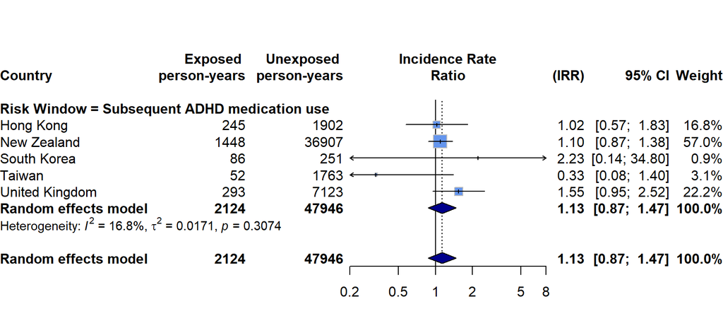

```r
library(meta)
rp_main_pre90<-subset(rp, Analysis=="Non-stimulants" & `Risk Window`=="Subsequent ADHD medication use" )
m.gen <- metagen(TE = log(IRR),
                 lower=log(IRRLCI),
                 upper=log(IRRUCI),
                 studlab = Country,
                 data = rp_main_pre90,
                 event.e=rp_main_pre90$Case_inc,
                 event.c=rp_main_pre90$Control_inc,
                 n.e=Case_total,
                 n.c=Control_total,
                 sm = "IRR",
                 fixed = FALSE,
                 random = TRUE,
                 subgroup=`Risk Window`,
                 method.tau = "DL")
library(forestplot)
library(dplyr)
main_pre90<-forest(m.gen,
       col.square="cornflowerblue",
        ff.heading = "bold",
col.i.inside.square="black",
       col.diamond.random = "darkblue",
       col.diamond.lines = "black",
       col.diamond.lines.random = "black",
       xlim = c(0.2,8),
       col.by="black",
       lab.e=NULL, lab.c=NULL, label=T,
         leftcols = c("studlab", "n.e", "n.c"),
       leftlabs=c("Country","Exposed \n person-years","Unexposed \n person-years" ),
       rightlabs=c("(IRR)","95% CI","Weight" ),
overall.hetstat=F,  test.subgroup=F)
```

## 3.4 Subgroup: male

```r
library(meta)

risk_main<-subset(risk, Analysis=="subm" )

m.gen <- metagen(TE = log(IRR),
                 lower=log(IRR_Lower),
                 upper=log(IRR_Upper),
                 studlab = Country,
                 data = risk_main,
                 event.e=risk_main$Case_inc,
                 event.c=risk_main$Control_inc,
                 n.e=Case_total,
                 n.c=Control_total,
                 sm = "IRR",
                 fixed = FALSE,
                 random = TRUE,
                 method.tau = "DL",
                 title = "Main analysis")
main<-forest(m.gen,
       col.square="cornflowerblue",
                 title = "Overall",
        ff.heading = "bold",
col.i.inside.square="black",
#col.study = "red",
       col.study = "black",col.diamond.random = "darkblue",
       col.diamond.lines = "black",
       col.diamond.lines.random = "black",
       xlim = c(0.2,5),
       col.by="navy",
       lab.e=NULL, lab.c=NULL,
label=T,
         leftcols = c("studlab", "n.e", "n.c"),
       leftlabs=c("Country","Exposed \n person-years","Unexposed \n person-years" ),
       rightlabs=c("(IRR)","95% CI","Weight" ))
```

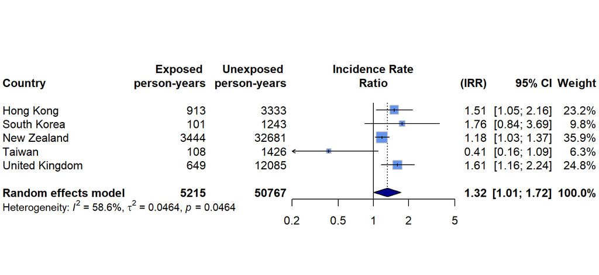

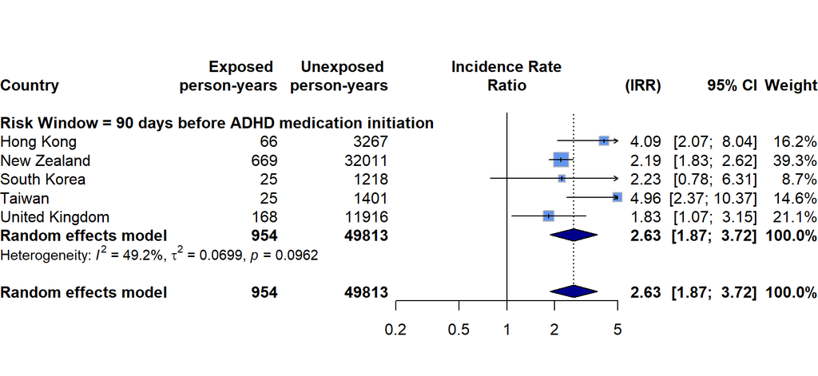

```r
library(meta)

rp_main_pre90<-subset(rp, Analysis=="Sub_male" & `Risk Window`=="90 days before ADHD medication initiation" )
m.gen <- metagen(TE = log(IRR),
                 lower=log(IRRLCI),
                 upper=log(IRRUCI),
                 studlab = Country,
                 data = rp_main_pre90,
                 event.e=rp_main_pre90$Case_inc,
                 event.c=rp_main_pre90$Control_inc,
                 n.e=Case_total,
                 n.c=Control_total,
                 sm = "IRR",
                 fixed = FALSE,
                 random = TRUE,
                 subgroup=`Risk Window`,
                 method.tau = "DL",
                 title = "Main analysis")
library(forestplot)
library(dplyr)

main_pre90<-forest(m.gen,
       col.square="cornflowerblue",
        ff.heading = "bold",
col.i.inside.square="black",
       col.diamond.random = "darkblue",
       col.diamond.lines = "black",
       col.diamond.lines.random = "black",
       xlim = c(0.2,5),
       col.by="black",
       lab.e=NULL, lab.c=NULL, label=T,
         leftcols = c("studlab", "n.e", "n.c"),
       leftlabs=c("Country","Exposed \n person-years","Unexposed \n person-years" ),
       rightlabs=c("(IRR)","95% CI","Weight" ),
overall.hetstat=F,  test.subgroup=F)
```

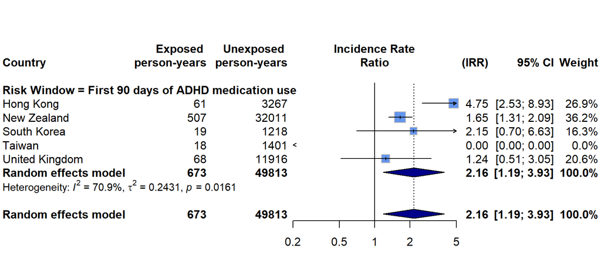

```r
library(meta)


rp_main_pre90<-subset(rp, Analysis=="Sub_male" & `Risk Window`=="First 90 days of ADHD medication use" )
m.gen <- metagen(TE = log(IRR),
                 lower=log(IRRLCI),
                 upper=log(IRRUCI),
                 studlab = Country,
                 data = rp_main_pre90,
                 event.e=rp_main_pre90$Case_inc,
                 event.c=rp_main_pre90$Control_inc,
                 n.e=Case_total,
                 n.c=Control_total,
                 sm = "IRR",
                 fixed = FALSE,
                 random = TRUE,
                 subgroup=`Risk Window`,
                 method.tau = "DL",
                 title = "Main analysis")
library(forestplot)
library(dplyr)

main_pre90<-forest(m.gen,
       col.square="cornflowerblue",
        ff.heading = "bold",
col.i.inside.square="black",
       col.diamond.random = "darkblue",
       col.diamond.lines = "black",
       col.diamond.lines.random = "black",
       xlim = c(0.2,5),
       col.by="black",
       lab.e=NULL, lab.c=NULL, label=T,
         leftcols = c("studlab", "n.e", "n.c"),
       leftlabs=c("Country","Exposed \n person-years","Unexposed \n person-years" ),
       rightlabs=c("(IRR)","95% CI","Weight" ),
overall.hetstat=F,  test.subgroup=F)
```

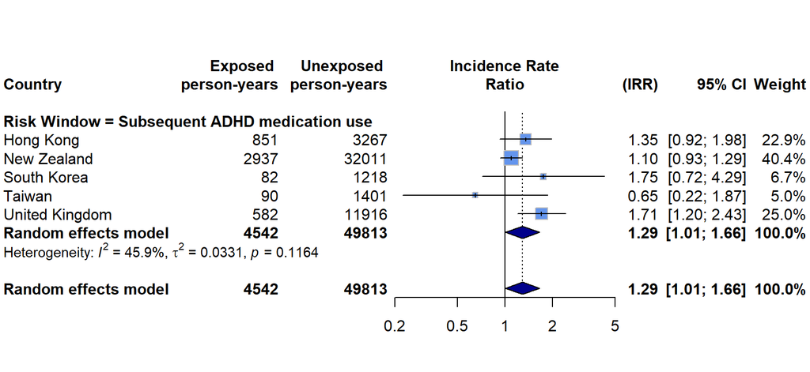

```r
library(meta)

rp_main_pre90<-subset(rp, Analysis=="Sub_male" & `Risk Window`=="Subsequent ADHD medication use" )
m.gen <- metagen(TE = log(IRR),
                 lower=log(IRRLCI),
                 upper=log(IRRUCI),
                 studlab = Country,
                 data = rp_main_pre90,
                 event.e=rp_main_pre90$Case_inc,
                 event.c=rp_main_pre90$Control_inc,
                 n.e=Case_total,
                 n.c=Control_total,
                 sm = "IRR",
                 fixed = FALSE,
                 random = TRUE,
                 subgroup=`Risk Window`,
                 method.tau = "DL")
library(forestplot)
library(dplyr)
main_pre90<-forest(m.gen,
       col.square="cornflowerblue",
        ff.heading = "bold",
col.i.inside.square="black",
       col.diamond.random = "darkblue",
       col.diamond.lines = "black",
       col.diamond.lines.random = "black",
       xlim = c(0.2,5),
       col.by="black",
       lab.e=NULL, lab.c=NULL, label=T,
         leftcols = c("studlab", "n.e", "n.c"),
       leftlabs=c("Country","Exposed \n person-years","Unexposed \n person-years" ),
       rightlabs=c("(IRR)","95% CI","Weight" ),
overall.hetstat=F,  test.subgroup=F)
```

## 3.5 Subgroup: female

```r
library(meta)


risk_main<-subset(risk, Analysis=="subf" )
m.gen <- metagen(TE = log(IRR),
                 lower=log(IRR_Lower),
                 upper=log(IRR_Upper),
                 studlab = Country,
                 data = risk_main,
                 event.e=rp_main_pre90$Case_inc,
                 event.c=rp_main_pre90$Control_inc,
                 n.e=Case_total,
                 n.c=Control_total,
                 sm = "IRR",
                 fixed = FALSE,
                 random = TRUE,
                 method.tau = "DL",
                 title = "Main analysis")

main<-forest(m.gen,
       col.square="cornflowerblue",
                 title = "Overall",
        ff.heading = "bold",
col.i.inside.square="black",
#col.study = "red",
       col.study = "black",col.diamond.random = "darkblue",
       col.diamond.lines = "black",
       col.diamond.lines.random = "black",
       xlim = c(0.2,5),
       col.by="navy",
       lab.e=NULL, lab.c=NULL,
label=T,
         leftcols = c("studlab", "n.e", "n.c"),
       leftlabs=c("Country","Exposed \n person-years","Unexposed \n person-years" ),
       rightlabs=c("(IRR)","95% CI","Weight" ))
```

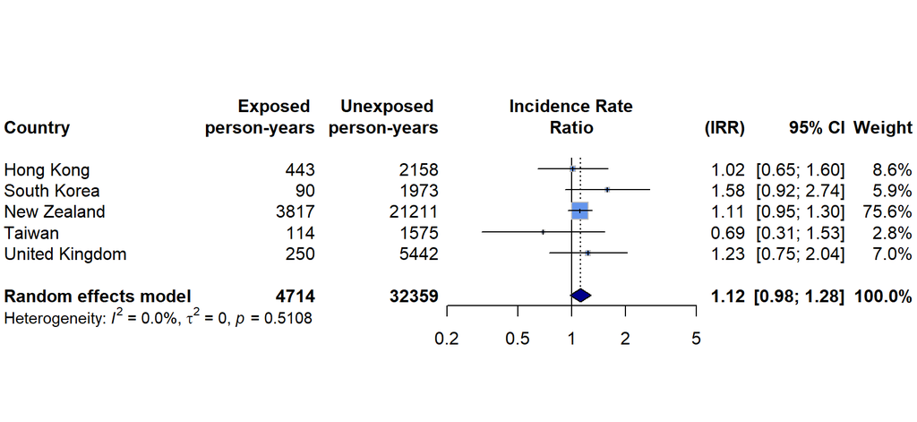

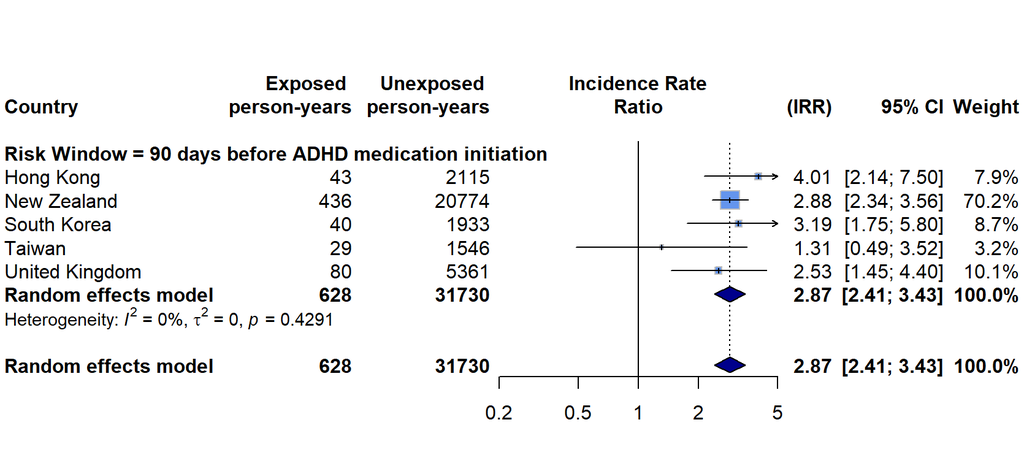

```r
library(meta)

rp_main_pre90<-subset(rp, Analysis=="Sub_female" & `Risk Window`=="90 days before ADHD medication initiation" )
m.gen <- metagen(TE = log(IRR),
                 lower=log(IRRLCI),
                 upper=log(IRRUCI),
                 studlab = Country,
                 data = rp_main_pre90,
                 event.e=rp_main_pre90$Case_inc,
                 event.c=rp_main_pre90$Control_inc,
                 n.e=Case_total,
                 n.c=Control_total,
                 sm = "IRR",
                 fixed = FALSE,
                 random = TRUE,
                subgroup=`Risk Window`,
                 method.tau = "DL",
                 title = "Main analysis")
library(forestplot)
library(dplyr)



main_pre90<-forest(m.gen,
       col.square="cornflowerblue",
        ff.heading = "bold",
col.i.inside.square="black",
       col.diamond.random = "darkblue",
       col.diamond.lines = "black",
       col.diamond.lines.random = "black",
       xlim = c(0.2,5),
       col.by="black",
       lab.e=NULL, lab.c=NULL, label=T,
         leftcols = c("studlab", "n.e", "n.c"),
       leftlabs=c("Country","Exposed \n person-years","Unexposed \n person-years" ),
       rightlabs=c("(IRR)","95% CI","Weight" ),
overall.hetstat=F,  test.subgroup=F)
```

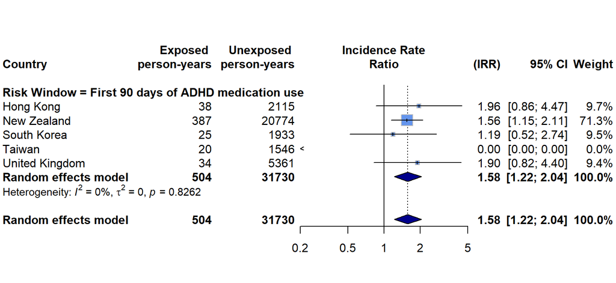

```r
library(meta)


rp_main_pre90<-subset(rp, Analysis=="Sub_female" & `Risk Window`=="First 90 days of ADHD medication use" )
m.gen <- metagen(TE = log(IRR),
                 lower=log(IRRLCI),
                 upper=log(IRRUCI),
                 studlab = Country,
                 data = rp_main_pre90,
                 event.e=rp_main_pre90$Case_inc,
                 event.c=rp_main_pre90$Control_inc,
                 n.e=Case_total,
                 n.c=Control_total,
                 sm = "IRR",
                 fixed = FALSE,
                 random = TRUE,
                 subgroup=`Risk Window`,
                 method.tau = "DL",
                 title = "Main analysis")
library(forestplot)
library(dplyr)

main_pre90<-forest(m.gen,
       col.square="cornflowerblue",
        ff.heading = "bold",
col.i.inside.square="black",
       col.diamond.random = "darkblue",
       col.diamond.lines = "black",
       col.diamond.lines.random = "black",
       xlim = c(0.2,5),
       col.by="black",
       lab.e=NULL, lab.c=NULL, label=T,
         leftcols = c("studlab", "n.e", "n.c"),
       leftlabs=c("Country","Exposed \n person-years","Unexposed \n person-years" ),
       rightlabs=c("(IRR)","95% CI","Weight" ),
overall.hetstat=F,  test.subgroup=F)
```

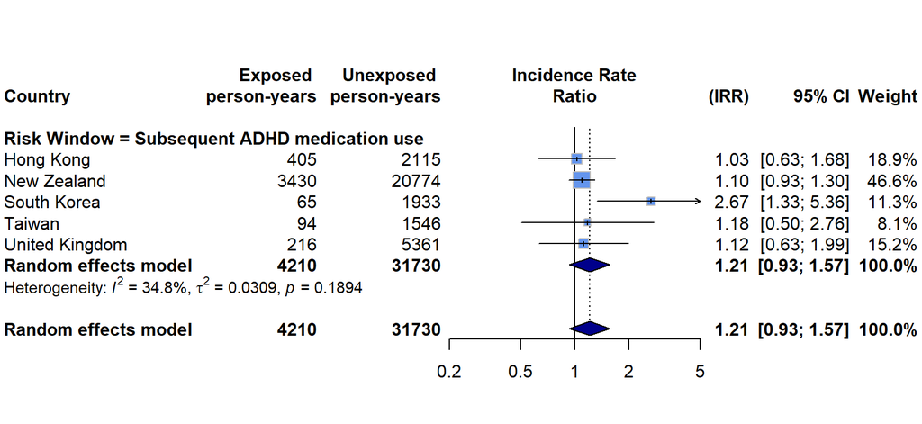

```r
library(meta)

rp_main_pre90<-subset(rp, Analysis=="Sub_female" & `Risk Window`=="Subsequent ADHD medication use" )
m.gen <- metagen(TE = log(IRR),
                 lower=log(IRRLCI),
                 upper=log(IRRUCI),
                 studlab = Country,
                 data = rp_main_pre90,
                 event.e=rp_main_pre90$Case_inc,
                 event.c=rp_main_pre90$Control_inc,
                 n.e=Case_total,
                 n.c=Control_total,
                 sm = "IRR",
                 fixed = FALSE,
                 random = TRUE,
                 subgroup=`Risk Window`,
                 method.tau = "DL")
library(forestplot)
library(dplyr)
main_pre90<-forest(m.gen,
       col.square="cornflowerblue",
        ff.heading = "bold",
col.i.inside.square="black",
       col.diamond.random = "darkblue",
       col.diamond.lines = "black",
       col.diamond.lines.random = "black",
       xlim = c(0.2,5),
       col.by="black",
       lab.e=NULL, lab.c=NULL, label=T,
         leftcols = c("studlab", "n.e", "n.c"),
       leftlabs=c("Country","Exposed \n person-years","Unexposed \n person-years" ),
       rightlabs=c("(IRR)","95% CI","Weight" ),
overall.hetstat=F,  test.subgroup=F)
```

## 3.6 Sensitivity 1: Recurrent suicide

```r
library(meta)


risk_main<-subset(risk, Analysis=="sen1" )
m.gen <- metagen(TE = log(IRR),
                 lower=log(IRR_Lower),
                 upper=log(IRR_Upper),
                 studlab = Country,
                 data = risk_main,
                 event.e=rp_main_pre90$Case_inc,
                 event.c=rp_main_pre90$Control_inc,
                 n.e=Case_total,
                 n.c=Control_total,
                 sm = "IRR",
                 fixed = FALSE,
                 random = TRUE,
                 method.tau = "DL",
                 title = "Main analysis")

main<-forest(m.gen,
       col.square="cornflowerblue",
                 title = "Overall",
        ff.heading = "bold",
col.i.inside.square="black",
#col.study = "red",
       col.study = "black",col.diamond.random = "darkblue",
       col.diamond.lines = "black",
       col.diamond.lines.random = "black",
       xlim = c(0.2,5),
       col.by="navy",
       lab.e=NULL, lab.c=NULL,
label=T,
         leftcols = c("studlab", "n.e", "n.c"),
       leftlabs=c("Country","Exposed \n person-years","Unexposed \n person-years" ),
       rightlabs=c("(IRR)","95% CI","Weight" ))
```

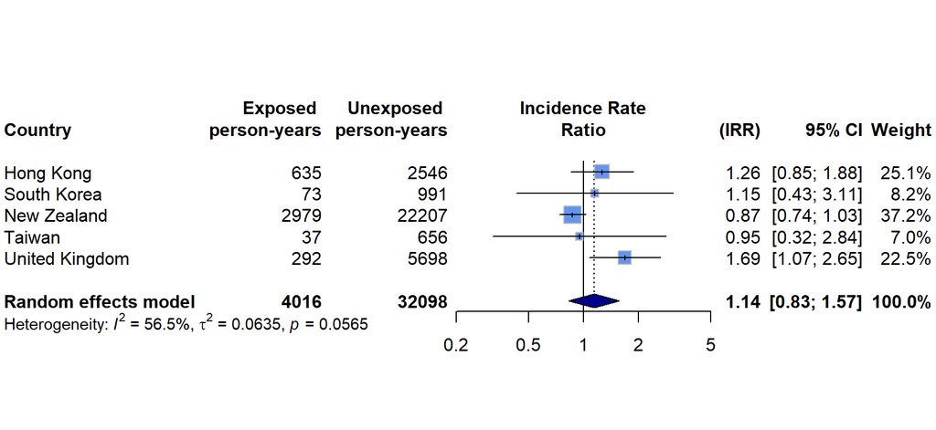

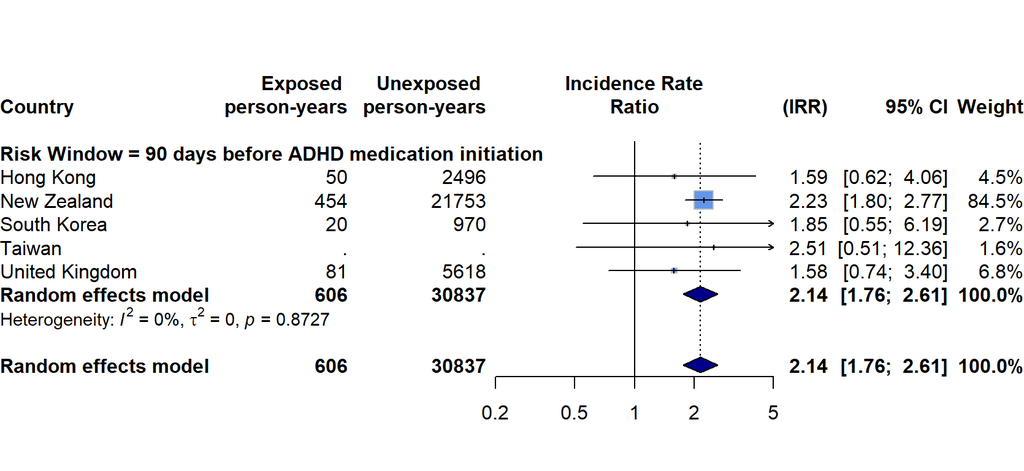

```r
library(meta)

rp_main_pre90<-subset(rp, Analysis=="SA_1" & `Risk Window`=="90 days before ADHD medication initiation" )
m.gen <- metagen(TE = log(IRR),
                 lower=log(IRRLCI),
                 upper=log(IRRUCI),
                 studlab = Country,
                 data = rp_main_pre90,
                 event.e=rp_main_pre90$Case_inc,
                 event.c=rp_main_pre90$Control_inc,
                 n.e=Case_total,
                 n.c=Control_total,
                 sm = "IRR",
                 fixed = FALSE,
                 random = TRUE,
                 subgroup=`Risk Window`,
                 method.tau = "DL",
                 title = "Main analysis")
library(forestplot)
library(dplyr)
main_pre90<-forest(m.gen,
       col.square="cornflowerblue",
        ff.heading = "bold",
col.i.inside.square="black",
       col.diamond.random = "darkblue",
       col.diamond.lines = "black",
       col.diamond.lines.random = "black",
       xlim = c(0.2,5),
       col.by="black",
       lab.e=NULL, lab.c=NULL, label=T,
         leftcols = c("studlab", "n.e", "n.c"),
       leftlabs=c("Country","Exposed \n person-years","Unexposed \n person-years" ),
       rightlabs=c("(IRR)","95% CI","Weight" ),
overall.hetstat=F,  test.subgroup=F)
```

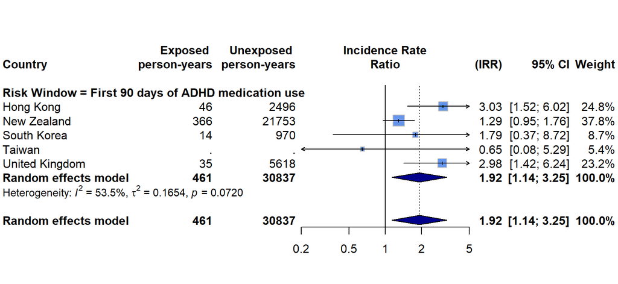

```r
library(meta)


rp_main_pre90<-subset(rp, Analysis=="SA_1" & `Risk Window`=="First 90 days of ADHD medication use")
m.gen <- metagen(TE = log(IRR),
                 lower=log(IRRLCI),
                 upper=log(IRRUCI),
                 studlab = Country,
                 data = rp_main_pre90,
                 event.e=rp_main_pre90$Case_inc,
                 event.c=rp_main_pre90$Control_inc,
                 n.e=Case_total,
                 n.c=Control_total,
                 sm = "IRR",
                 fixed = FALSE,
                 random = TRUE,
                 subgroup=`Risk Window`,
                 method.tau = "DL",
                 title = "Main analysis")
library(forestplot)
library(dplyr)
main_pre90<-forest(m.gen,
       col.square="cornflowerblue",
        ff.heading = "bold",
col.i.inside.square="black",
       col.diamond.random = "darkblue",
       col.diamond.lines = "black",
       col.diamond.lines.random = "black",
       xlim = c(0.2,5),
       col.by="black",
       lab.e=NULL, lab.c=NULL, label=T,
         leftcols = c("studlab", "n.e", "n.c"),
       leftlabs=c("Country","Exposed \n person-years","Unexposed \n person-years" ),
       rightlabs=c("(IRR)","95% CI","Weight" ),
overall.hetstat=F,  test.subgroup=F)
```

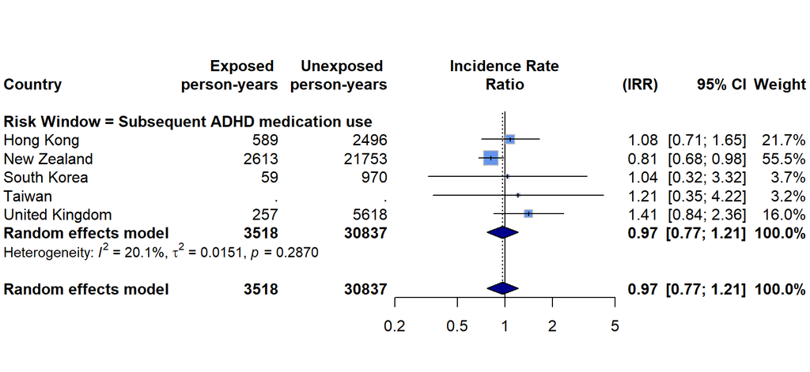

```r
library(meta)

rp_main_pre90<-subset(rp, Analysis=="SA_1" & `Risk Window`=="Subsequent ADHD medication use" & IRR!=0)
m.gen <- metagen(TE = log(IRR),
                 lower=log(IRRLCI),
                 upper=log(IRRUCI),
                 studlab = Country,
                 data = rp_main_pre90,
                 event.e=rp_main_pre90$Case_inc,
                 event.c=rp_main_pre90$Control_inc,
                 n.e=Case_total,
                 n.c=Control_total,
                 sm = "IRR",
                 fixed = FALSE,
                 random = TRUE,
                 subgroup=`Risk Window`,
                 method.tau = "DL")
library(forestplot)
library(dplyr)
main_pre90<-forest(m.gen,
       col.square="cornflowerblue",
        ff.heading = "bold",
col.i.inside.square="black",
       col.diamond.random = "darkblue",
       col.diamond.lines = "black",
       col.diamond.lines.random = "black",
       xlim = c(0.2,5),
       col.by="black",
       lab.e=NULL, lab.c=NULL, label=T,
         leftcols = c("studlab", "n.e", "n.c"),
       leftlabs=c("Country","Exposed \n person-years","Unexposed \n person-years" ),
       rightlabs=c("(IRR)","95% CI","Weight" ),
overall.hetstat=F,  test.subgroup=F)
```

## 3.7 Sensitivity 2: Remove people with death

```r
library(meta)


risk_main<-subset(risk, Analysis=="sen2" )
m.gen <- metagen(TE = log(IRR),
                 lower=log(IRR_Lower),
                 upper=log(IRR_Upper),
                 studlab = Country,
                 data = risk_main,
                 event.e=rp_main_pre90$Case_inc,
                 event.c=rp_main_pre90$Control_inc,
                 n.e=Case_total,
                 n.c=Control_total,
                 sm = "IRR",
                 fixed = FALSE,
                 random = TRUE,
                 method.tau = "DL",
                 title = "Main analysis")

main<-forest(m.gen,
       col.square="cornflowerblue",
                 title = "Overall",
        ff.heading = "bold",
col.i.inside.square="black",
#col.study = "red",
       col.study = "black",col.diamond.random = "darkblue",
       col.diamond.lines = "black",
       col.diamond.lines.random = "black",
       xlim = c(0.2,5),
       col.by="navy",
       lab.e=NULL, lab.c=NULL,
label=T,
         leftcols = c("studlab", "n.e", "n.c"),
       leftlabs=c("Country","Exposed \n person-years","Unexposed \n person-years" ),
       rightlabs=c("(IRR)","95% CI","Weight" ))
```

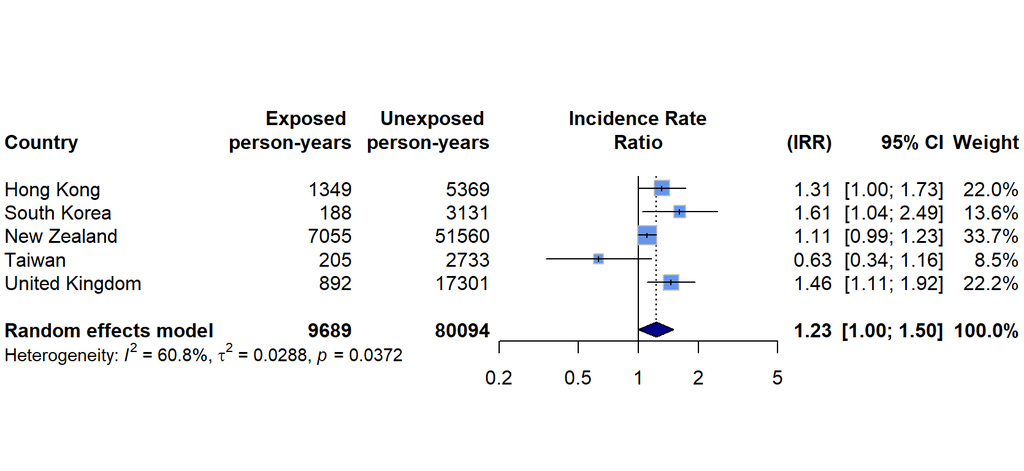

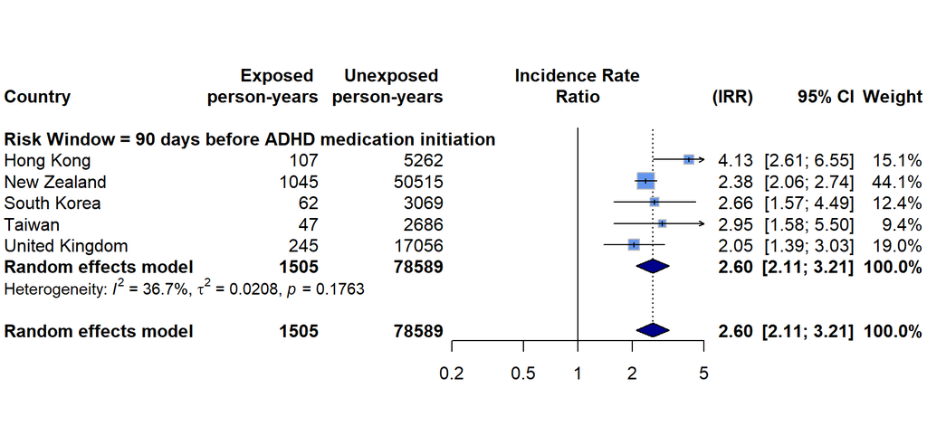

```r
library(meta)

rp_main_pre90<-subset(rp, Analysis=="SA_2" & `Risk Window`=="90 days before ADHD medication initiation" )
m.gen <- metagen(TE = log(IRR),
                 lower=log(IRRLCI),
                 upper=log(IRRUCI),
                 studlab = Country,
                 data = rp_main_pre90,
                 event.e=rp_main_pre90$Case_inc,
                 event.c=rp_main_pre90$Control_inc,
                 n.e=Case_total,
                 n.c=Control_total,
                 sm = "IRR",
                 fixed = FALSE,
                 random = TRUE,
                 subgroup=`Risk Window`,
                 method.tau = "DL",
                 title = "Main analysis")
library(forestplot)
library(dplyr)
main_pre90<-forest(m.gen,
       col.square="cornflowerblue",
        ff.heading = "bold",
col.i.inside.square="black",
       col.diamond.random = "darkblue",
       col.diamond.lines = "black",
       col.diamond.lines.random = "black",
       xlim = c(0.2,5),
       col.by="black",
       lab.e=NULL, lab.c=NULL, label=T,
         leftcols = c("studlab", "n.e", "n.c"),
       leftlabs=c("Country","Exposed \n person-years","Unexposed \n person-years" ),
       rightlabs=c("(IRR)","95% CI","Weight" ),
overall.hetstat=F,  test.subgroup=F)
```

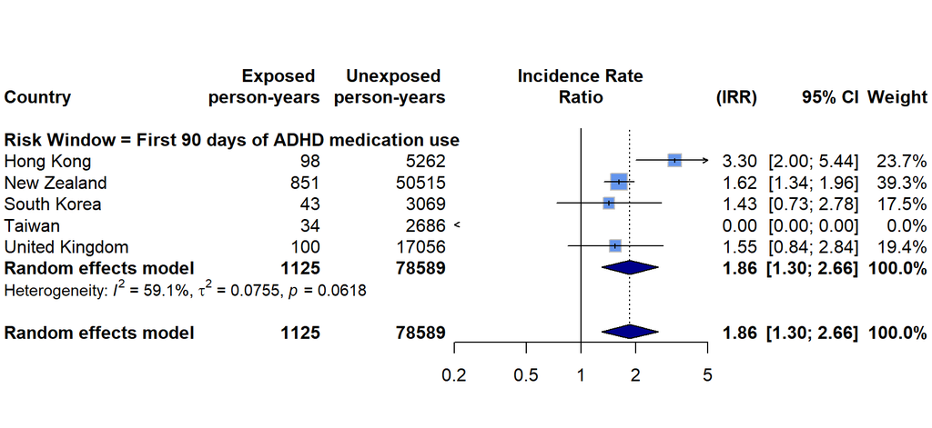

```r
library(meta)
rp_main_pre90<-subset(rp, Analysis=="SA_2" & `Risk Window`=="First 90 days of ADHD medication use" )
m.gen <- metagen(TE = log(IRR),
                 lower=log(IRRLCI),
                 upper=log(IRRUCI),
                 studlab = Country,
                 data = rp_main_pre90,
                 event.e=rp_main_pre90$Case_inc,
                 event.c=rp_main_pre90$Control_inc,
                 n.e=Case_total,
                 n.c=Control_total,
                 sm = "IRR",
                 fixed = FALSE,
                 random = TRUE,
                 subgroup=`Risk Window`,
                 method.tau = "DL",
                 title = "Main analysis")
library(forestplot)
library(dplyr)
main_pre90<-forest(m.gen,
       col.square="cornflowerblue",
        ff.heading = "bold",
col.i.inside.square="black",
       col.diamond.random = "darkblue",
       col.diamond.lines = "black",
       col.diamond.lines.random = "black",
       xlim = c(0.2,5),
       col.by="black",
       lab.e=NULL, lab.c=NULL, label=T,
         leftcols = c("studlab", "n.e", "n.c"),
       leftlabs=c("Country","Exposed \n person-years","Unexposed \n person-years" ),
       rightlabs=c("(IRR)","95% CI","Weight" ),
overall.hetstat=F,  test.subgroup=F)
```

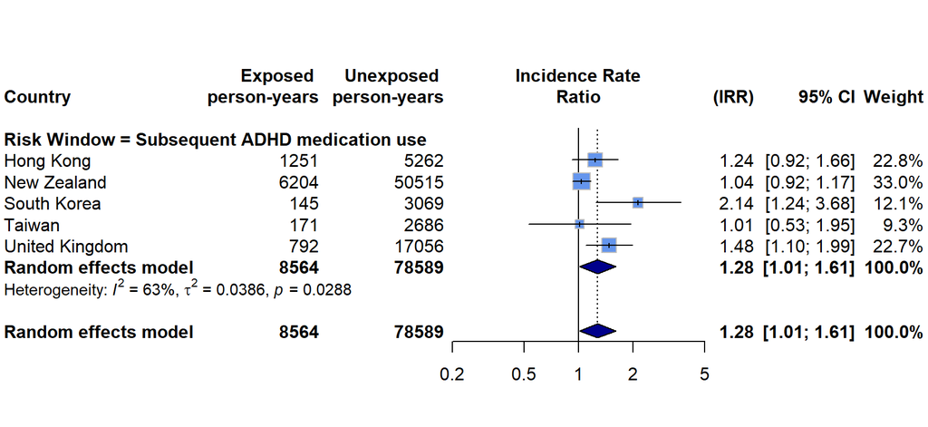

```r
library(meta)

rp_main_pre90<-subset(rp, Analysis=="SA_2" & `Risk Window`=="Subsequent ADHD medication use" )
m.gen <- metagen(TE = log(IRR),
                 lower=log(IRRLCI),
                 upper=log(IRRUCI),
                 studlab = Country,
                 data = rp_main_pre90,
                 event.e=rp_main_pre90$Case_inc,
                 event.c=rp_main_pre90$Control_inc,
                 n.e=Case_total,
                 n.c=Control_total,
                 sm = "IRR",
                 fixed = FALSE,
                 random = TRUE,
                 subgroup=`Risk Window`,
                 method.tau = "DL")
library(forestplot)
library(dplyr)
main_pre90<-forest(m.gen,
       col.square="cornflowerblue",
        ff.heading = "bold",
col.i.inside.square="black",
       col.diamond.random = "darkblue",
       col.diamond.lines = "black",
       col.diamond.lines.random = "black",
       xlim = c(0.2,5),
       col.by="black",
       lab.e=NULL, lab.c=NULL, label=T,
         leftcols = c("studlab", "n.e", "n.c"),
       leftlabs=c("Country","Exposed \n person-years","Unexposed \n person-years" ),
       rightlabs=c("(IRR)","95% CI","Weight" ),
overall.hetstat=F,  test.subgroup=F)
```

## 3.8 Sensitivity 3: Extend exposure duration by 1 week:

```r
library(meta)
risk_main<-subset(risk, Analysis=="sen3" )
m.gen <- metagen(TE = log(IRR),
                 lower=log(IRR_Lower),
                 upper=log(IRR_Upper),
                 studlab = Country,
                 data = risk_main,
                 event.e=rp_main_pre90$Case_inc,
                 event.c=rp_main_pre90$Control_inc,
                 n.e=Case_total,
                 n.c=Control_total,
                 sm = "IRR",
                 fixed = FALSE,
                 random = TRUE,
                 method.tau = "DL",
                 title = "Main analysis")

main<-forest(m.gen,
       col.square="cornflowerblue",
                 title = "Overall",
        ff.heading = "bold",
col.i.inside.square="black",
#col.study = "red",
       col.study = "black",col.diamond.random = "darkblue",
       col.diamond.lines = "black",
       col.diamond.lines.random = "black",
       xlim = c(0.2,5),
       col.by="navy",
       lab.e=NULL, lab.c=NULL,
label=T,
         leftcols = c("studlab", "n.e", "n.c"),
       leftlabs=c("Country","Exposed \n person-years","Unexposed \n person-years" ),
       rightlabs=c("(IRR)","95% CI","Weight" ))
```

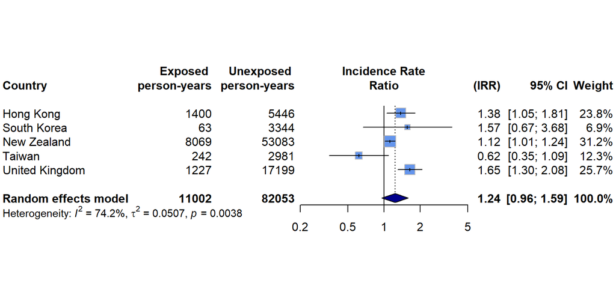

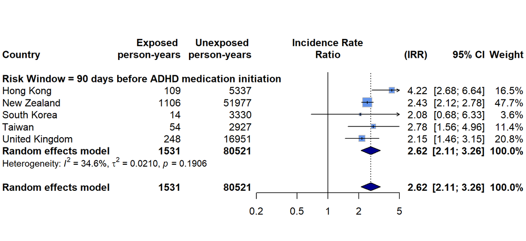

```r
library(meta)

rp_main_pre90<-subset(rp, Analysis=="SA_3" & `Risk Window`=="90 days before ADHD medication initiation" )
m.gen <- metagen(TE = log(IRR),
                 lower=log(IRRLCI),
                 upper=log(IRRUCI),
                 studlab = Country,
                 data = rp_main_pre90,
                 event.e=rp_main_pre90$Case_inc,
                 event.c=rp_main_pre90$Control_inc,
                 n.e=Case_total,
                 n.c=Control_total,
                 sm = "IRR",
                 fixed = FALSE,
                 random = TRUE,
                 subgroup=`Risk Window`,
                 method.tau = "DL",
                 title = "Main analysis")
library(forestplot)
library(dplyr)
main_pre90<-forest(m.gen,
       col.square="cornflowerblue",
        ff.heading = "bold",
col.i.inside.square="black",
       col.diamond.random = "darkblue",
       col.diamond.lines = "black",
       col.diamond.lines.random = "black",
       xlim = c(0.2,5),
       col.by="black",
       lab.e=NULL, lab.c=NULL, label=T,
         leftcols = c("studlab", "n.e", "n.c"),
       leftlabs=c("Country","Exposed \n person-years","Unexposed \n person-years" ),
       rightlabs=c("(IRR)","95% CI","Weight" ),
overall.hetstat=F,  test.subgroup=F)
```

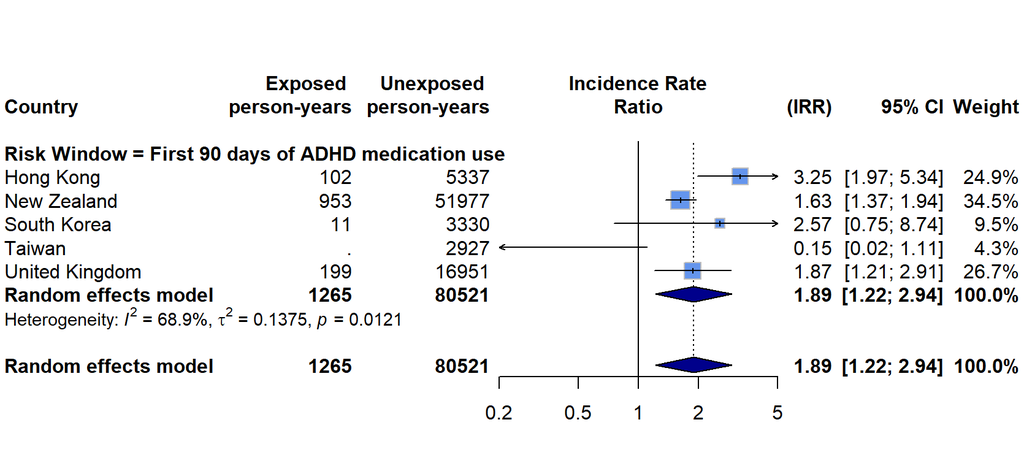

```r
library(meta)


rp_main_pre90<-subset(rp, Analysis=="SA_3" & `Risk Window`=="First 90 days of ADHD medication use" )
m.gen <- metagen(TE = log(IRR),
                 lower=log(IRRLCI),
                 upper=log(IRRUCI),
                 studlab = Country,
                 data = rp_main_pre90,
                 event.e=rp_main_pre90$Case_inc,
                 event.c=rp_main_pre90$Control_inc,
                 n.e=Case_total,
                 n.c=Control_total,
                 sm = "IRR",
                 fixed = FALSE,
                 random = TRUE,
                 subgroup=`Risk Window`,
                 method.tau = "DL",
                 title = "Main analysis")
library(forestplot)
library(dplyr)
main_pre90<-forest(m.gen,
       col.square="cornflowerblue",
        ff.heading = "bold",
col.i.inside.square="black",
       col.diamond.random = "darkblue",
       col.diamond.lines = "black",
       col.diamond.lines.random = "black",
       xlim = c(0.2,5),
       col.by="black",
       lab.e=NULL, lab.c=NULL, label=T,
         leftcols = c("studlab", "n.e", "n.c"),
       leftlabs=c("Country","Exposed \n person-years","Unexposed \n person-years" ),
       rightlabs=c("(IRR)","95% CI","Weight" ),
overall.hetstat=F,  test.subgroup=F)
```

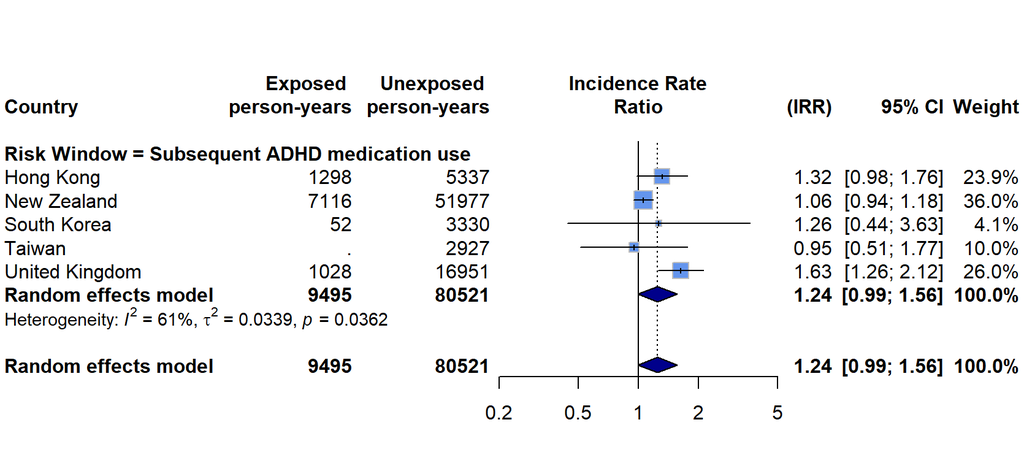

```r
library(meta)

rp_main_pre90<-subset(rp, Analysis=="SA_3" & `Risk Window`=="Subsequent ADHD medication use" )
m.gen <- metagen(TE = log(IRR),
                 lower=log(IRRLCI),
                 upper=log(IRRUCI),
                 studlab = Country,
                 data = rp_main_pre90,
                 event.e=rp_main_pre90$Case_inc,
                 event.c=rp_main_pre90$Control_inc,
                 n.e=Case_total,
                 n.c=Control_total,
                 sm = "IRR",
                 fixed = FALSE,
                 random = TRUE,
                 subgroup=`Risk Window`,
                 method.tau = "DL")
library(forestplot)
library(dplyr)
main_pre90<-forest(m.gen,
       col.square="cornflowerblue",
        ff.heading = "bold",
col.i.inside.square="black",
       col.diamond.random = "darkblue",
       col.diamond.lines = "black",
       col.diamond.lines.random = "black",
       xlim = c(0.2,5),
       col.by="black",
       lab.e=NULL, lab.c=NULL, label=T,
         leftcols = c("studlab", "n.e", "n.c"),
       leftlabs=c("Country","Exposed \n person-years","Unexposed \n person-years" ),
       rightlabs=c("(IRR)","95% CI","Weight" ),
overall.hetstat=F,  test.subgroup=F)
```